# Predicting Airbnb Prices in NYC

Bryan Phillips

1/10/2020

## Overview

For this project, I have decided to utilize a large open-source dataset of Airbnb’s in New York City in order to create a price prediction model using machine learning techniques from throughout this course. The main technique I will utilize are matrix factorization and regularization.

The dataset contains around 50,000 unique observation on individual Airbnb locations and their price point for 2019. This dataset is available at Kaggle.com at the link here: https://www.kaggle.com/dgomonov/new-york-city-airbnb-open-data

The dataset contains 16 variables summarized below, but the main information I will use for this analysis are Neighbourhood, Room Type, and Price.

```
##        id                                         name
##  Min.   :    2539   Hillside Hotel                  :   18
##  1st Qu.: 9471945   Home away from home             :   17
##  Median :19677284                                   :   16
##  Mean   :19017143   New york Multi-unit building    :   16
##  3rd Qu.:29152178   Brooklyn Apartment              :   12
##  Max.   :36487245   Loft Suite @ The Box House Hotel:   11
##                     (Other)                         :48805
##     host_id                 host_name        neighbourhood_group
##  Min.   :     2438   Michael     :  417   Bronx        : 1091
##  1st Qu.:  7822033   David       :  403   Brooklyn     :20104
##  Median : 30793816   Sonder (NYC):  327   Manhattan    :21661
##  Mean   : 67620011   John        :  294   Queens       : 5666
##  3rd Qu.:107434423   Alex        :  279   Staten Island:  373
##  Max.   :274321313   Blueground  :  232
##                      (Other)     :46943
##             neighbourhood      latitude       longitude
##  Williamsburg      : 3920   Min.   :40.50   Min.   :-74.24
##  Bedford-Stuyvesant: 3714   1st Qu.:40.69   1st Qu.:-73.98
##  Harlem            : 2658   Median :40.72   Median :-73.96
##  Bushwick          : 2465   Mean   :40.73   Mean   :-73.95
##  Upper West Side   : 1971   3rd Qu.:40.76   3rd Qu.:-73.94
##  Hell's Kitchen    : 1958   Max.   :40.91   Max.   :-73.71
##  (Other)           :32209
##            room_type         price         minimum_nights
##  Entire home/apt:25409   Min.   :    0.0   Min.   :   1.00
##  Private room   :22326   1st Qu.:   69.0   1st Qu.:   1.00
##  Shared room    : 1160   Median :  106.0   Median :   3.00
##                          Mean   :  152.7   Mean   :   7.03
##                          3rd Qu.:  175.0   3rd Qu.:   5.00
##                          Max.   :10000.0   Max.   :1250.00
##
##  number_of_reviews  last_review    reviews_per_month
##  Min.   :  0.00           :10052   Min.   : 0.010
##  1st Qu.:  1.00    6/23/19: 1413   1st Qu.: 0.190
##  Median :  5.00    7/1/19 : 1359   Median : 0.720
##  Mean   : 23.27    6/30/19: 1341   Mean   : 1.373
##  3rd Qu.: 24.00    6/24/19:  875   3rd Qu.: 2.020
##  Max.   :629.00    7/7/19 :  718   Max.   :58.500
##                    (Other):33137   NA's   :10052
##  calculated_host_listings_count availability_365
##  Min.   :  1.000                Min.   :  0.0
##  1st Qu.:  1.000                1st Qu.:  0.0
##  Median :  1.000                Median : 45.0
##  Mean   :  7.144                Mean   :112.8
##  3rd Qu.:  2.000                3rd Qu.:227.0
##  Max.   :327.000                Max.   :365.0
##
```

The way in which I will be evaluating the overall performance of the model will be to calculate Root Mean Squared Error (RMSE) of each model.

All of the code for this analysis is available on my github linked here: https://github.com/bkphillips/NYC_Airbnb_Price_Predict

## Analysis

First looking at the price information, I notice it contains some pretty large outliers as seen in the density plot below:

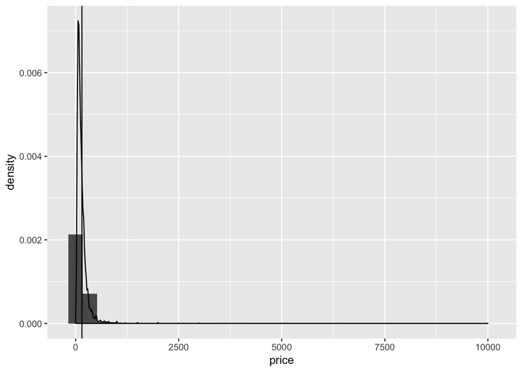

I then decided to look at the log distribution below, where the average price of $152 becomes more apparent. (average shown with vertical line)

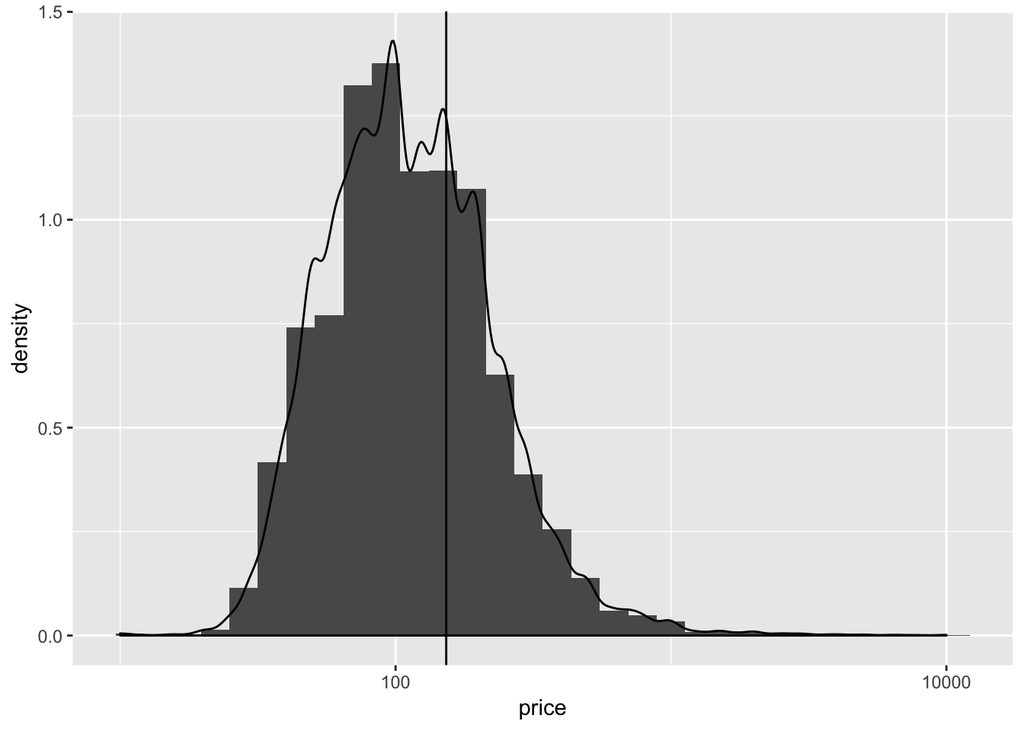

The other key descriptive variable are Neighbourhood Group, Neighborhood, and Room type.

There are 221 unique neighborhoods, so for the purpose of describing the dataset I will mostly show the 5 main groups in which they fall into. There are also 3 main room types: Entire home, private room, or shared room. Below you can see a count of the types of room in the different areas of NYC. You can see the majority of locations are in Manhattan and Brooklyn. They are also mostly entire home/apt. or private rooms.

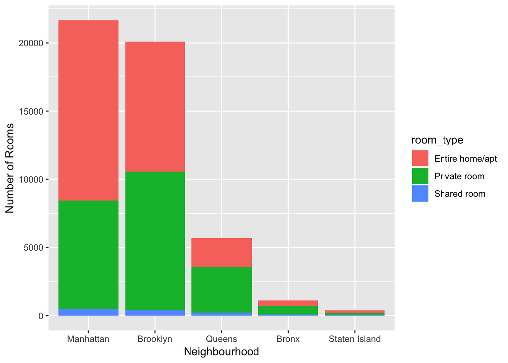

Below is the average price for each neighborhood with Manhattan noticeably more expensive compared to the other neighbourhoods.

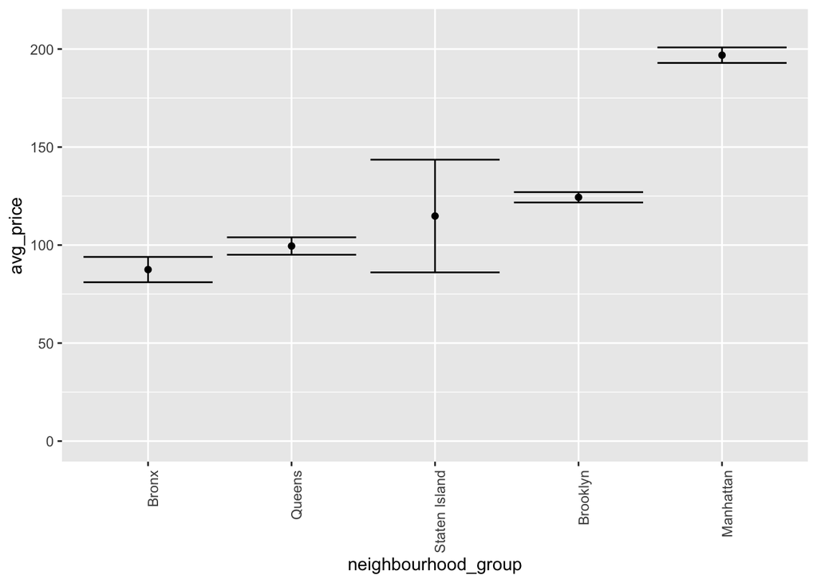

Below are the average price of the neighborhoods that have over 1,000 Airbnb locations. Midtown is most expensive and Bushwick is the cheapest.

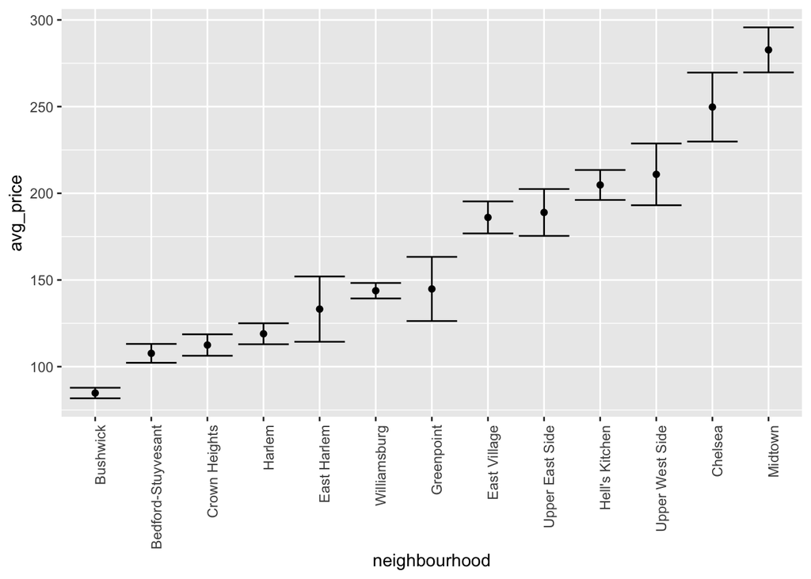

Below is the variation of average price by room type with Entire home/apt. being drastically more expensive

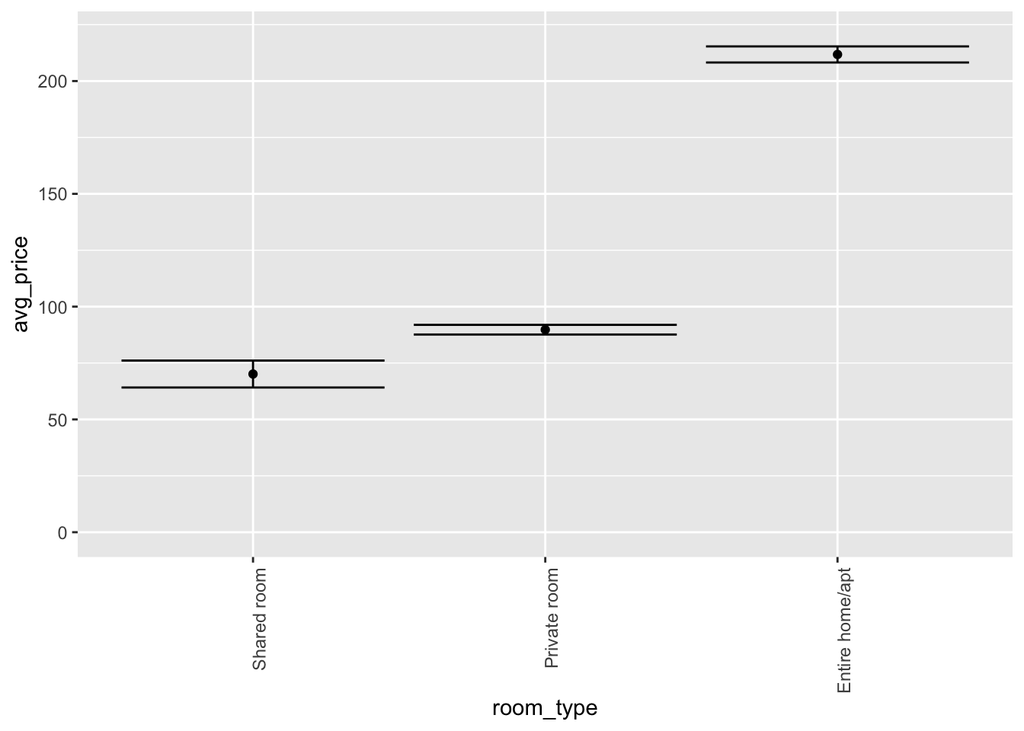

In order to create my training and testing datasets, I decided to remove locations with a price of $0 or anything above $500 based on the outliers that were seen in the initial density plots. I then partitioned the data into 70% for the training and 30% for the testing set.

# Modeling and Results

I then began testing just the average first model on the price data, which gave a RMSE of 85.4. When I added the neighborhood group effects (b_g), this brought it down to 80.6. When testing neighborhood effects (b_n), it had a much better performance of 74.6, so I decided to stay with just b_n. The fourth model then used the room type effects (b_t) which significantly brought down the RMSE to 64.5.

Then I then tried regularlizing the data because I figured that neighbourhoods that had more listings probably have more trustworthy prices that are more accurate. This only brought down my RSME to 64.1.

Below is a table of results of modeling on my training data and testing my final model on my training dataset:

| method | RMSE |
| --- | --- |
| Just the average | 85.41663 |
| Neighbourhood Group Mode | 80.63411 |
| Neighbourhood Model | 74.57021 |
| Neighbourhood + Room Type Model | 64.45839 |
| Regularized Neighbourhood + Room Type Model | 64.18415 |
| Testing Final Regularized Neighbourhood + Room Type Model | 63.17012 |

Below is my final model used on the test set and the plot of the RSME’s that were used to fine tune the lambda’s for the regularization technique. You can see the optimal lambda for minimized RMSE is around 40:

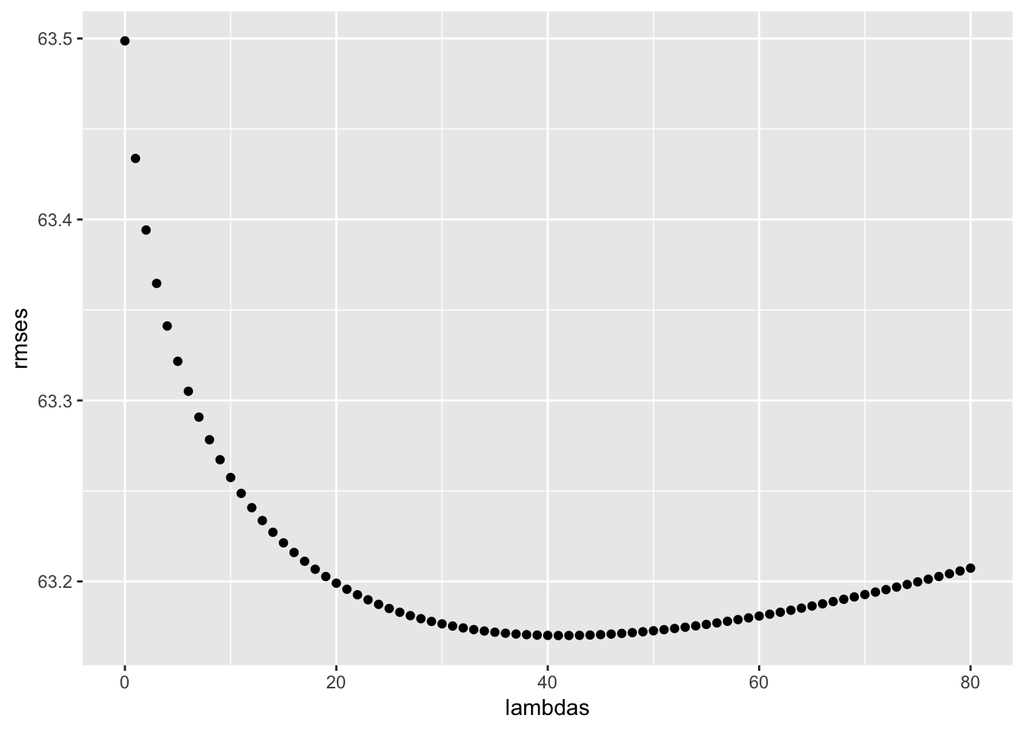

```r
#Testing the Final Regularized Model of b_n + b_t
lambdas <- seq(0, 80, 1)
rmses <- sapply(lambdas, function(l){
  mu <- mean(train_set$price)
  b_n <- train_set %>%
    group_by(neighbourhood) %>%
    summarize(b_n = sum(price - mu)/(n()+l))
  b_t <- train_set %>%
    left_join(b_n, by="neighbourhood") %>%
    group_by(room_type) %>%
    summarize(b_t = sum(price - b_n - mu)/(n()+l))
  predicted_price <-
    test_set %>%
    left_join(b_n, by = "neighbourhood") %>%
    left_join(b_t, by = "room_type") %>%
    rowwise()  %>%
    mutate(pred = sum( mu, b_n, b_t, na.rm=TRUE)) %>%
    .$pred
  return(RMSE(predicted_price, test_set$price))
})
qplot(lambdas, rmses)
```

I then plotted the predicted prices to see how they compared with the actual prices. The plot is also colored by the room type. It looks as though even though I removed large outliers, the more expensive locations are causing a large amount of the error. It also looks as though some neighbourhoods are also clumping into columns.

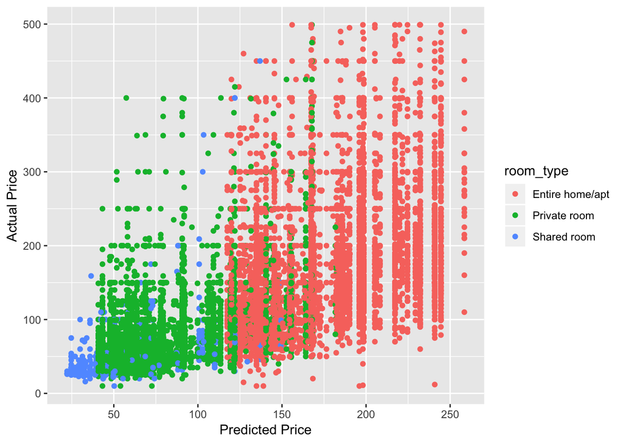

```r
#Creating predication comparison of final model to analyze difference of prediction and actual price
lambda <- lambdas[which.min(rmses)]

mu <- mean(train_set$price)
b_n <- train_set %>%
  group_by(neighbourhood) %>%
  summarize(b_n = sum(price - mu)/(n()+lambda))
b_t <- train_set %>%
  left_join(b_n, by="neighbourhood") %>%
  group_by(room_type) %>%
  summarize(b_t = sum(price - b_n - mu)/(n()+lambda))
predicted_price <-
  test_set %>%
  left_join(b_n, by = "neighbourhood") %>%
  left_join(b_t, by = "room_type") %>%
  rowwise()  %>%
  mutate(pred = sum( mu, b_n, b_t, na.rm=TRUE))

#Looking at distribution of room type
ggplot(predicted_price, aes(pred, price, color=room_type)) +
  theme(axis.title = element_text(), axis.title.x = element_text()) +
  geom_point() +
  ylab("Actual Price") +
  xlab("Predicted Price")
```

[output not shown]

# Conclusion